```python
from IPython.display import HTML

HTML('''<script>
code_show=true;
function code_toggle() {
 if (code_show){
 $('div.input').hide();
 } else {
 $('div.input').show();
 }
 code_show = !code_show
}
$( document ).ready(code_toggle);
</script>
<form action="javascript:code_toggle()"><input type="submit" value="Click here to toggle on/off the raw code."></form>''')
```

# Motivation

We extend the theoretical model from **Anderson et al. (2013), Steering User Behavior with Badges** to a model that is grounded in the users' behaviour on Stack Overflow. From the model, we gain insights about how people act in the presence of a badge and how they repond to badge incentives.

**Original model:**

$$ U(x_a) = \sum\limits_{b \in B} I_b(a) V_b + \theta \sum\limits_{i=1}^{n+1}x_a^i \cdot U(x_{a+e_i}) - g(x_a, \mathbf{p}) $$

The probability of acting depends on:

1. The user specific base distribution ($\mathbf{p}$).
2. The value of a badge (not specified if this is user specific or assumed external to the user) ($V_b$).
3. The cost that a user pays for deviating from the base distribution ($g$).
4. (some discount parameter $\theta$)

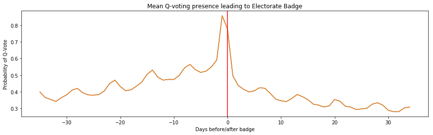

```python
s = np.concatenate([seq.numpy() for seq, kernel, out, prox, badge_date in train_loader], axis=0)
o = np.concatenate([out.numpy() for seq, kernel, out, prox, badge_date in train_loader], axis=0)

plt.figure(figsize=(15,4))
plt.plot(np.arange(-5*7, 5*7), np.mean(s[:,:,5], axis=0))
plt.plot(np.arange(-5*7, 5*7), np.mean(o, axis=0))
plt.axvline(0, c='red')
plt.title('Mean Q-voting presence leading to Electorate Badge')
plt.xlabel('Days before/after badge')
plt.ylabel('Probability of Q-Vote')

plt.show()
```

### Express as a graphical model

- A user will only deviate if the badge value outweighs the cost of changing his/her default behaviour.
- It follows that (2) and (3) can be understood as a deviation from the user's base distribution as the user approaches the badge boundary. This deviation is non-negative before the badge is achieved and non-positive after the badge has been achieved.
- **A simplifying assumption:** the ''badge deviation'' (called kernel from now on) is a function that depends on the user's proximity to the badge and is a shared response between all users. This assumption can be relaxed at a later stage.

### Express as a graphical model

We obtain the following graphical model for a user's interaction behaviour (p is the base distribution local to a user and $\beta$ is the badge kernel:

[figure not shown]

### Address Weaknesses of baseline model:

There is evidence that users do not respond uniformly to the badge. **Solution**: add a user-specific parameter that controls the strength of the effect of the badge response (shown below). $S \in (0,1)$ is the parameter that controls the strenth of a user's adherence to the kernel. P and S are both local latent variables, specific to each user.

[figure not shown]

**Note:** It is possible that users do not respond with the same functional form to a badge (not addressed yet).

# Brief motivation for strength parameter (S):

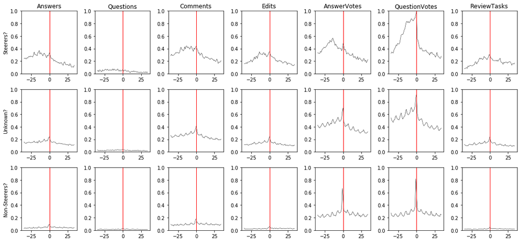

```python
fig, axes = plt.subplots(3,7, figsize=(15,7))

for i in range(7):
    for j in range(3):
        mask = proximity[:,5*7] <= .1
        if j == 0:
            mask = proximity[:,5*7] > .9
        elif j == 1:
            mask = (proximity[:,5*7] <= .9) & (proximity[:,5*7] > .1)

        axes[j,i].plot(
                np.arange(-len(proximity[0])//2,len(proximity[0])//2),
                np.mean(s[mask,:,i], axis=0)
            , lw=.5, c='black')
        axes[j,i].axvline(0, c='red', lw=1)
        axes[j,i].set_ylim([0,1])

    axes[0,i].set_title(so_data.ACTIONS[i])

axes[0,0].set_ylabel('Steerers?')
axes[1,0].set_ylabel('Unknown?')
axes[2,0].set_ylabel('Non-Steerers?')

plt.tight_layout()
plt.show()
```

## Notes:

- Different populations have different responses to the badge in the proximity of the badge.
- The population that starts with the lowest count of actions (in the 5 week period) has the biggest deviance from 0 in their response

# Method

Compare and contrast the models, investigate the functional form of the steering kernel and relax modeling assumptions.

## Baseline (model 1)

Model assumptions:

(1) Every user has their own "base distribution".

(2) Base distribution does not change between weeks of interaction.

[figure not shown]

```python
loss_fn = lambda x1,x2,x3,x4: models.BCE_loss_function(x1,x2,x3,x4, data_shape=dset_shape, act_choice=5)
_ = test(model_base, loss_fn)
```

```
Average Test loss: 40.7442
```

## Linear parameter (model 2)

Model assumptions:

(1) Every user has their own "base distribution".

(2) Base distribution does not change between weeks of interaction.

(3) All users experience a linear strictly positive change in probability of acting as they approach the badge boundary. Thereafter they experience a non-positive change in probability in acting.

[figure not shown]

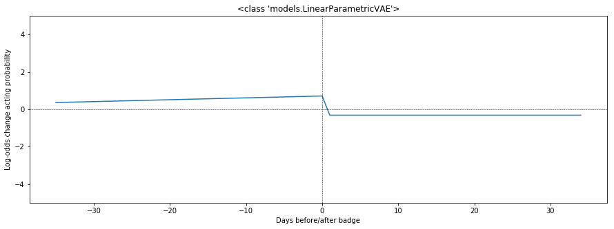

```python
plot_kernel(dset_train, model, dset_shape, device)
```

```python
loss_fn = lambda x1,x2,x3,x4: models.BCE_loss_function(x1,x2,x3,x4, data_shape=dset_shape, act_choice=5)
_ = test(model, loss_fn)
```

```
Average Test loss: 40.1143
```

## Personalised Linear (model 3)

Model assumptions - same as Linear but:

1) A user-specific steering parameter $\in (0,1)$ that controls the effect of the deviance from normal acting.

[figure not shown]

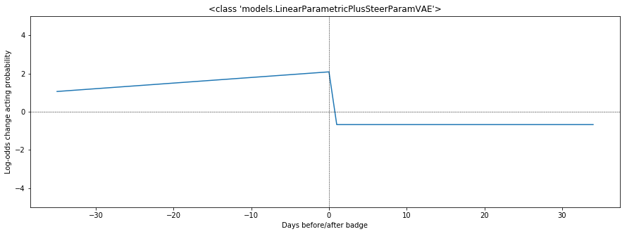

```python
plot_kernel(dset_train, model, dset_shape, device)
```

```python
loss_fn = lambda x1,x2,x3,x4: models.BCE_loss_function(x1,x2,x3,x4, data_shape=dset_shape, act_choice=5)
ladent_dim = test(model, loss_fn, get_latent_par=[19])
```

```
Average Test loss: 39.2619
```

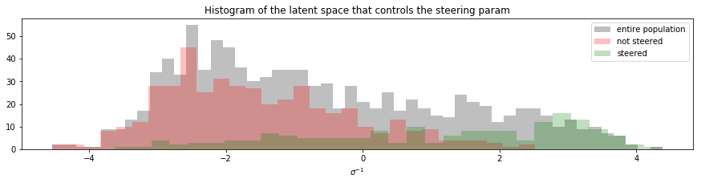

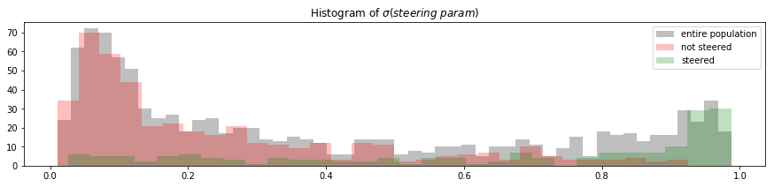

```python
sigmoid = lambda x: np.exp(x)/(1+np.exp(x))
w = model.positive_steer_weight[0].detach().numpy()

plt.figure(figsize=(15,3))
plt.hist(w*ladent_dim[19], label='entire population', bins=50, alpha=.5, color='grey')
plt.hist(w*ladent_dim['not_steered'], label='not steered', alpha=.25, color='red', bins=30)
plt.hist(w*ladent_dim['steered'], label='steered', alpha=.25, color='green', bins=30)
plt.legend(loc='best')
plt.title('Histogram of the latent space that controls the steering param')
plt.xlabel("$\sigma^{-1}$")
plt.show()

plt.figure(figsize=(15,3))
plt.hist(sigmoid(w*ladent_dim[19]), label='entire population', bins=50, alpha=.5, color='grey')
plt.hist(sigmoid(w*ladent_dim['not_steered']), label='not steered', alpha=.25, color='red', bins=30)
plt.hist(sigmoid(w*ladent_dim['steered']), label='steered', alpha=.25, color='green', bins=30)
plt.legend(loc='best')
plt.title('Histogram of $\sigma(steering\ param)$')
plt.show()
```

# Fully parameterised (model 4)

Model assumptions:

(1) Every user has their own "base distribution".

(2) Base distribution does not change between weeks of interaction.

(3) All users experience a non-negative change in probability of acting before the badge is achieved and a non-positive change in probability of acting before the badge is achieved.

[figure not shown]

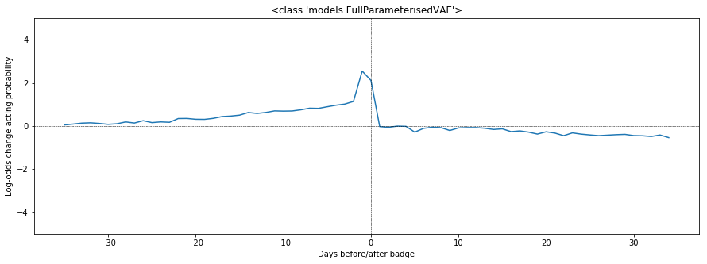

```python
plot_kernel(dset_train, model, dset_shape, device)
```

```python
loss_fn = lambda x1,x2,x3,x4: models.BCE_loss_function(x1,x2,x3,x4, data_shape=dset_shape, act_choice=5)
_ = test(model, loss_fn)
```

```
Average Test loss: 39.0297
```

# Fully parameterised, personal param (model 5)

Model assumptions - same as full parameterised but:

1) A user-specific steering parameter $\in (0,1)$ that controls the effect of the deviance from normal acting.

[figure not shown]

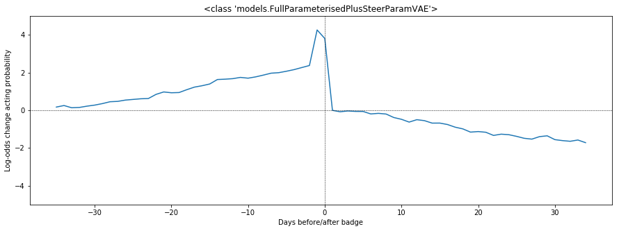

```python
plot_kernel(dset_train, model, dset_shape, device)
```

```python
loss_fn = lambda x1,x2,x3,x4: models.BCE_loss_function(x1,x2,x3,x4, data_shape=dset_shape, act_choice=5)
ladent_dim = test(model, loss_fn, get_latent_par=[19])
```

```
Average Test loss: 38.5821
```

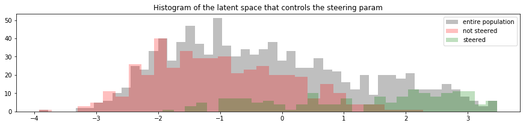

```python
w = model.positive_steer_weight[0].detach().numpy()

plt.figure(figsize=(15,3))
plt.hist(w*ladent_dim[19], label='entire population', bins=50, alpha=.5, color='grey')
plt.hist(w*ladent_dim['not_steered'], label='not steered', alpha=.25, color='red', bins=30)
plt.hist(w*ladent_dim['steered'], label='steered', alpha=.25, color='green', bins=30)
plt.legend(loc='best')
plt.title('Histogram of the latent space that controls the steering param')
plt.show()
```

# Compare the results:

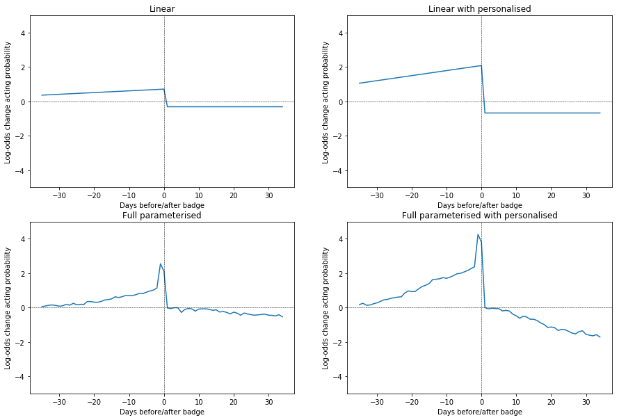

```python
# compare kernels
fig, axes = plt.subplots(2,2,figsize=(15,10))
axes = axes.flatten()
mdls = [model_lin, model_per_lin, model_fp, model_per_fp]
title = ['Linear', 'Linear with personalised', 'Full parameterised', 'Full parameterised with personalised']
for i, m in enumerate(mdls):
    plot_kernel(dset_train, m, dset_shape, device, ax=axes[i], title=title[i])
plt.show()
```

```python
# compare loss
print("Baseline: \t\t", end='')
ladent_dim = test(model_base, loss_fn, get_latent_par=[19])
print("Linear: \t\t", end='')
ladent_dim = test(model_lin, loss_fn, get_latent_par=[19])
print("Linear + Personalised: \t", end='')
ladent_dim = test(model_per_lin, loss_fn, get_latent_par=[19])
print("Full P: \t\t", end='')
ladent_dim = test(model_fp, loss_fn, get_latent_par=[19])
print("Full P + Personalised: \t", end='')
ladent_dim = test(model_per_fp, loss_fn, get_latent_par=[19])
```

```
Baseline: 		Average Test loss: 40.8441
Linear: 		Average Test loss: 40.0458
Linear + Personalised: 	Average Test loss: 39.2855
Full P: 		Average Test loss: 39.0970
Full P + Personalised: 	Average Test loss: 38.5056
```

# Next Steps

## Study the trajectories of the inferences from Full-parameterised model:

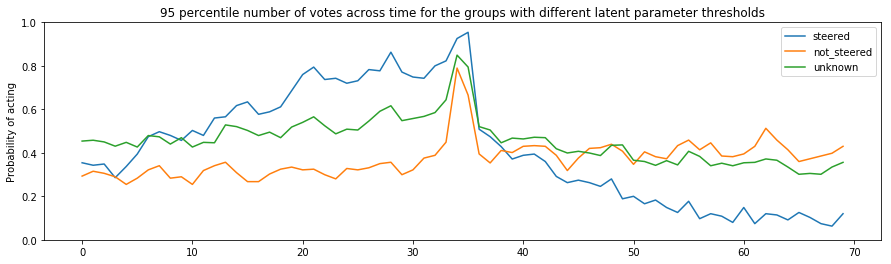

```python
trajs = np.array(latent_pars['steered'])
trajs2 = np.array(latent_pars['not_steered'])
trajs3 = np.array(latent_pars['unknown'])

plt.figure(figsize=(15,4))
plt.plot(np.mean(trajs, axis=0),  label='steered')
plt.plot(np.mean(trajs2, axis=0), label='not_steered')
plt.plot(np.mean(trajs3, axis=0), label='unknown')
plt.title('95 percentile number of votes across time for the groups with different latent parameter thresholds')
plt.legend(loc='best')
plt.ylim([0,1])
plt.ylabel('Probability of acting')
plt.show()
```